# White Wine Exploratory Data Analysis

## Structure and introduction of the data set:

In this project I will explore and analyze the white wine dataset to see how the different input variables determine the quality of the white wine. First, we will start by looking at the distribution of each variable. Then, we will look at the correlation between the different variables. Finally, we will select three graphs to summarize our findings. Let’s start by loading the data and have a brief look at the variables:

Dimensions of the dataset:

```
## [1] 4898   12
```

Input variables (based on physicochemical tests):  
1 - fixed acidity (tartaric acid - g / dm^3)  
2 - volatile acidity (acetic acid - g / dm^3)  
3 - citric acid (g / dm^3)  
4 - residual sugar (g / dm^3)  
5 - chlorides (sodium chloride - g / dm^3  
6 - free sulfur dioxide (mg / dm^3)  
7 - total sulfur dioxide (mg / dm^3)  
8 - density (g / cm^3)  
9 - pH  
10 - sulphates (potassium sulphate - g / dm3)  
11 - alcohol (% by volume)  
Output variable (based on sensory data):  
12 - quality (score between 0 and 10)

Type of each variable:

```
## 'data.frame':    4898 obs. of  12 variables:
##  $ fixed.acidity       : num  7 6.3 8.1 7.2 7.2 8.1 6.2 7 6.3 8.1 ...
##  $ volatile.acidity    : num  0.27 0.3 0.28 0.23 0.23 0.28 0.32 0.27 0.3 0.22 ...
##  $ citric.acid         : num  0.36 0.34 0.4 0.32 0.32 0.4 0.16 0.36 0.34 0.43 ...
##  $ residual.sugar      : num  20.7 1.6 6.9 8.5 8.5 6.9 7 20.7 1.6 1.5 ...
##  $ chlorides           : num  0.045 0.049 0.05 0.058 0.058 0.05 0.045 0.045 0.049 0.044 ...
##  $ free.sulfur.dioxide : num  45 14 30 47 47 30 30 45 14 28 ...
##  $ total.sulfur.dioxide: num  170 132 97 186 186 97 136 170 132 129 ...
##  $ density             : num  1.001 0.994 0.995 0.996 0.996 ...
##  $ pH                  : num  3 3.3 3.26 3.19 3.19 3.26 3.18 3 3.3 3.22 ...
##  $ sulphates           : num  0.45 0.49 0.44 0.4 0.4 0.44 0.47 0.45 0.49 0.45 ...
##  $ alcohol             : num  8.8 9.5 10.1 9.9 9.9 10.1 9.6 8.8 9.5 11 ...
##  $ quality             : int  6 6 6 6 6 6 6 6 6 6 ...
```

**summary of the variables:**

```
##  fixed.acidity    volatile.acidity  citric.acid     residual.sugar
##  Min.   : 3.800   Min.   :0.0800   Min.   :0.0000   Min.   : 0.600
##  1st Qu.: 6.300   1st Qu.:0.2100   1st Qu.:0.2700   1st Qu.: 1.700
##  Median : 6.800   Median :0.2600   Median :0.3200   Median : 5.200
##  Mean   : 6.855   Mean   :0.2782   Mean   :0.3342   Mean   : 6.391
##  3rd Qu.: 7.300   3rd Qu.:0.3200   3rd Qu.:0.3900   3rd Qu.: 9.900
##  Max.   :14.200   Max.   :1.1000   Max.   :1.6600   Max.   :65.800
##    chlorides       free.sulfur.dioxide total.sulfur.dioxide
##  Min.   :0.00900   Min.   :  2.00      Min.   :  9.0
##  1st Qu.:0.03600   1st Qu.: 23.00      1st Qu.:108.0
##  Median :0.04300   Median : 34.00      Median :134.0
##  Mean   :0.04577   Mean   : 35.31      Mean   :138.4
##  3rd Qu.:0.05000   3rd Qu.: 46.00      3rd Qu.:167.0
##  Max.   :0.34600   Max.   :289.00      Max.   :440.0
##     density             pH          sulphates         alcohol
##  Min.   :0.9871   Min.   :2.720   Min.   :0.2200   Min.   : 8.00
##  1st Qu.:0.9917   1st Qu.:3.090   1st Qu.:0.4100   1st Qu.: 9.50
##  Median :0.9937   Median :3.180   Median :0.4700   Median :10.40
##  Mean   :0.9940   Mean   :3.188   Mean   :0.4898   Mean   :10.51
##  3rd Qu.:0.9961   3rd Qu.:3.280   3rd Qu.:0.5500   3rd Qu.:11.40
##  Max.   :1.0390   Max.   :3.820   Max.   :1.0800   Max.   :14.20
##     quality
##  Min.   :3.000
##  1st Qu.:5.000
##  Median :6.000
##  Mean   :5.878
##  3rd Qu.:6.000
##  Max.   :9.000
```

## Univariate Plots Section

In this section, and before we look at the relations between the variables and how they affect each other, We will look at each variable individually to have a better understanding of its structure and distribution shape. knowing the shape of the data will help us to have some expectations about how the graphs will be later on, and to check the outliers and remove them if needed.

let us start with the quality column:

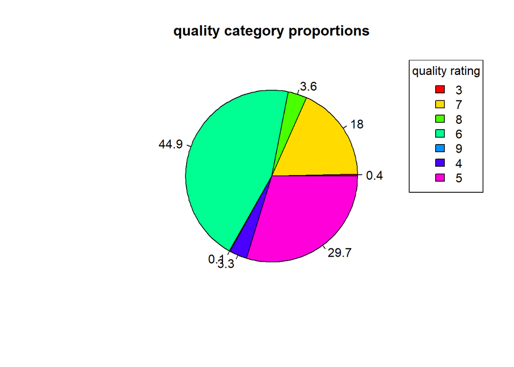

> It seems like the quality rating 5 and 6 make the most of the qualities. Let us see the count of each category.

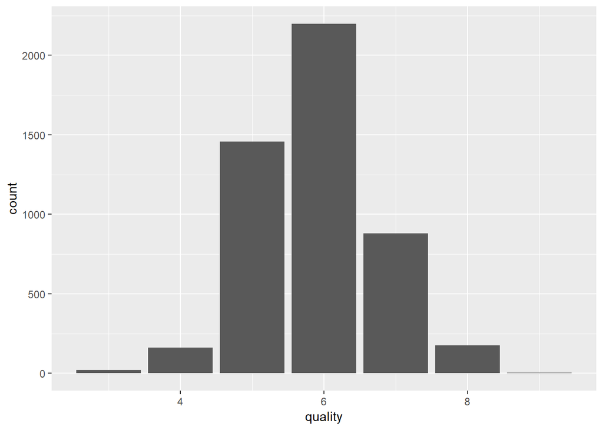

```
##
##    3    4    5    6    7    8    9
##   20  163 1457 2198  880  175    5
```

> As we can see thier are very few high and low quality wines. So, we can create a new variable called **quality.buckets** with type **Factor**. Containing the following values.  
> value range  
> - low (1-4]  
> - good (4-6]  
> - high (6-10]

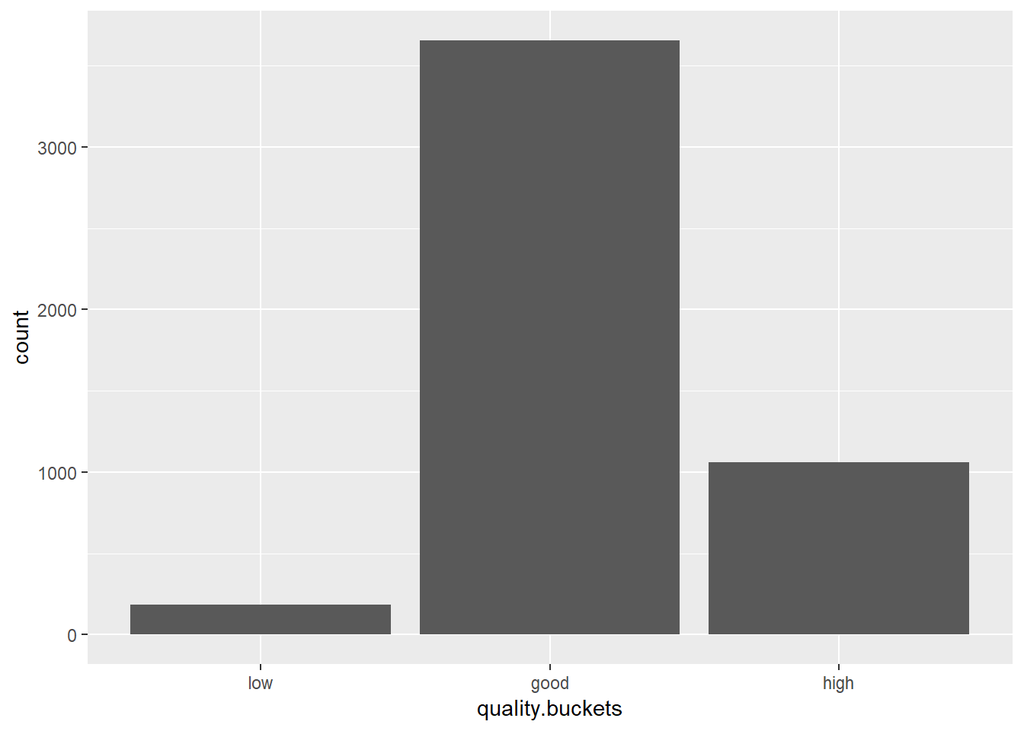

#### let us have a look at input variables now:

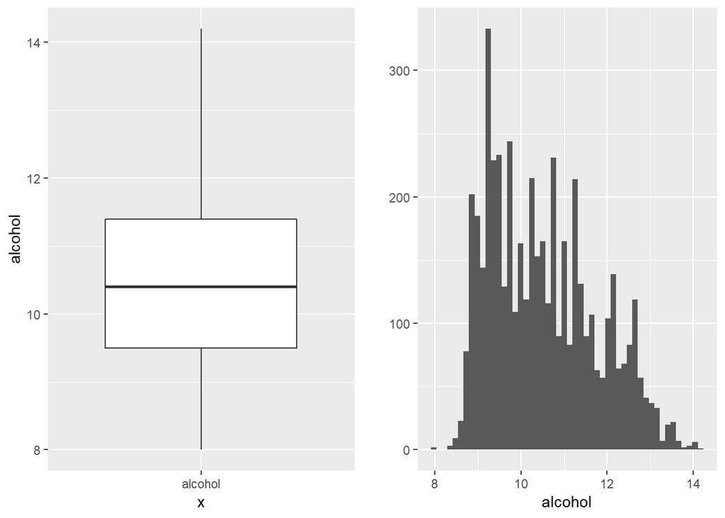

```
##    Min. 1st Qu.  Median    Mean 3rd Qu.    Max.
##    8.00    9.50   10.40   10.51   11.40   14.20
```

> If we look at the graph and the values of the median and the mean, we can see that alcohol distribution is slightly right-skewed.

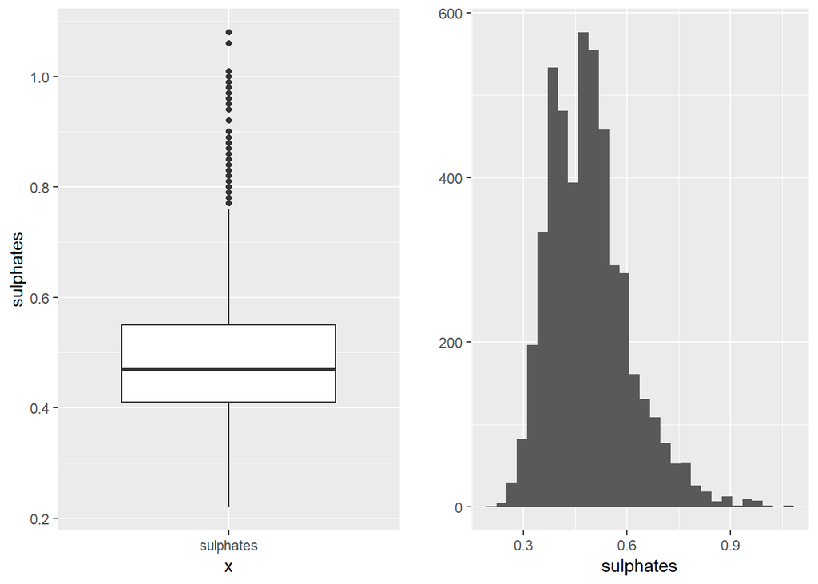

```
##    Min. 1st Qu.  Median    Mean 3rd Qu.    Max.
##  0.2200  0.4100  0.4700  0.4898  0.5500  1.0800
```

> The sulphates distribution is slightly right-skewed, I think if we removed the outliers, we will get a symmetric distribution.

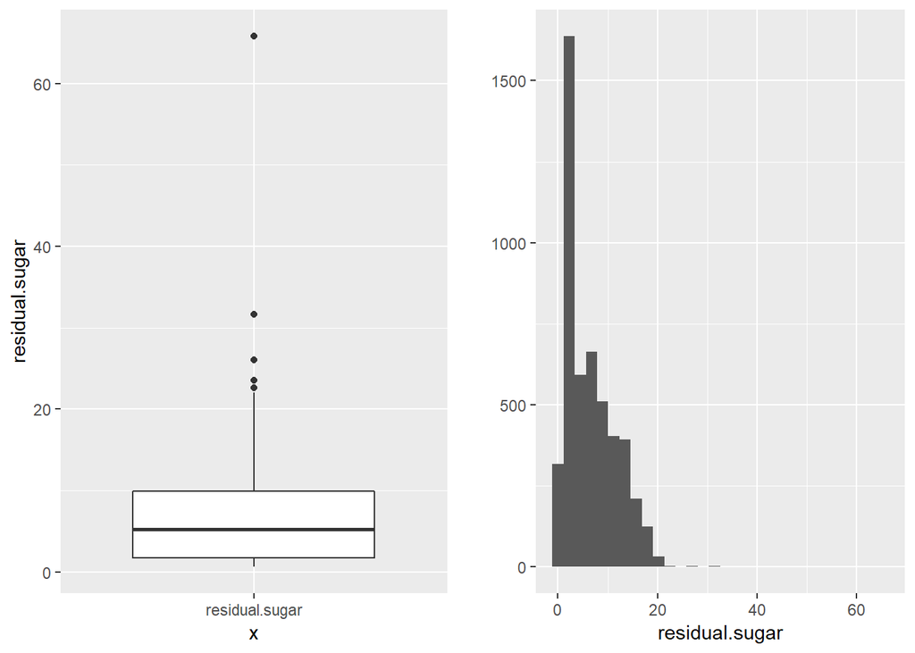

```
##    Min. 1st Qu.  Median    Mean 3rd Qu.    Max.
##   0.600   1.700   5.200   6.391   9.900  65.800
```

> The distribution of the Residual Sugar is highly right-skewed, with an extreme outlier at 65.8 (g / dm^3).

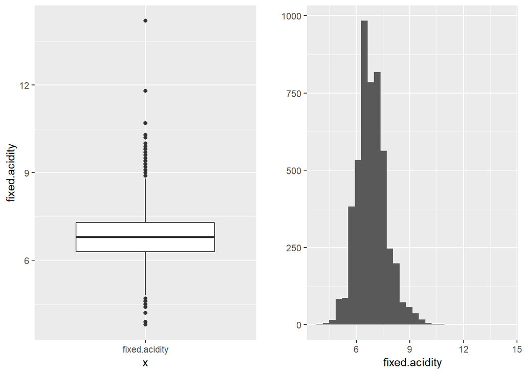

```
##    Min. 1st Qu.  Median    Mean 3rd Qu.    Max.
##   3.800   6.300   6.800   6.855   7.300  14.200
```

> Again the graph is slightly right-skewed because of the outliers.

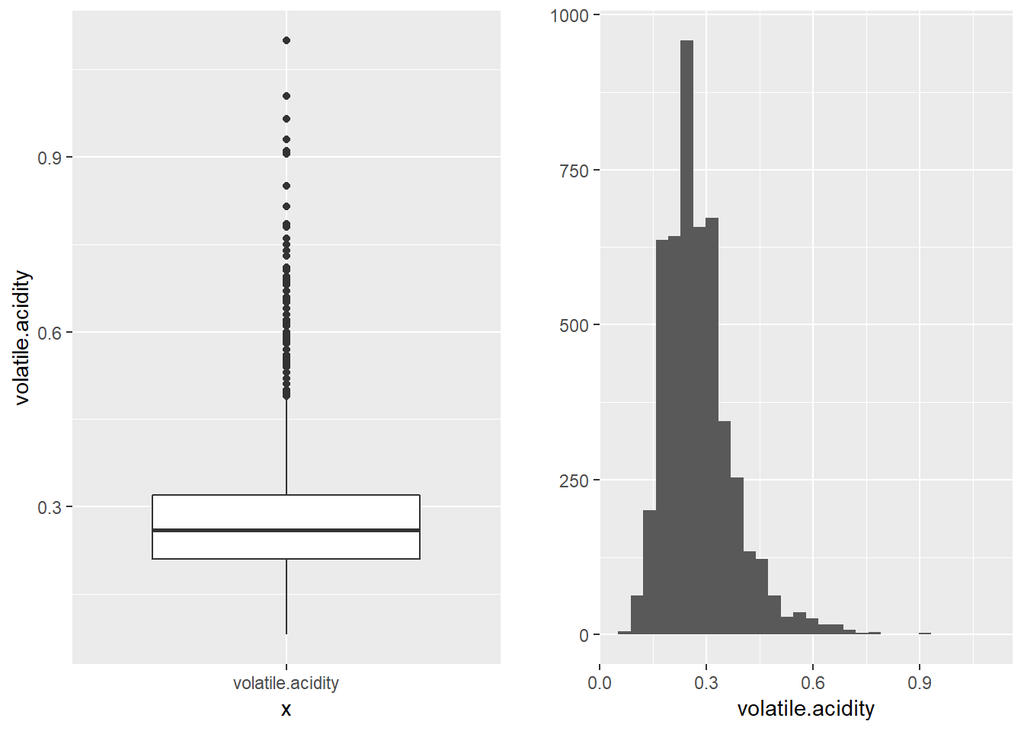

```
##    Min. 1st Qu.  Median    Mean 3rd Qu.    Max.
##  0.0800  0.2100  0.2600  0.2782  0.3200  1.1000
```

> The Volatile Acidity distribution is right-skewed with a lot of outliers.

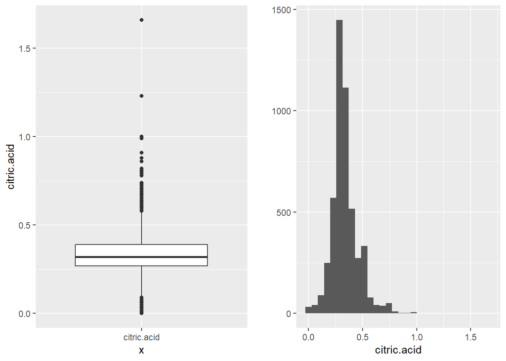

```
##    Min. 1st Qu.  Median    Mean 3rd Qu.    Max.
##  0.0000  0.2700  0.3200  0.3342  0.3900  1.6600
```

> The distribution of the Citric Acid is slightly right-skewed. Also, the distribution have some extreme outliers and a peak at 0.26.

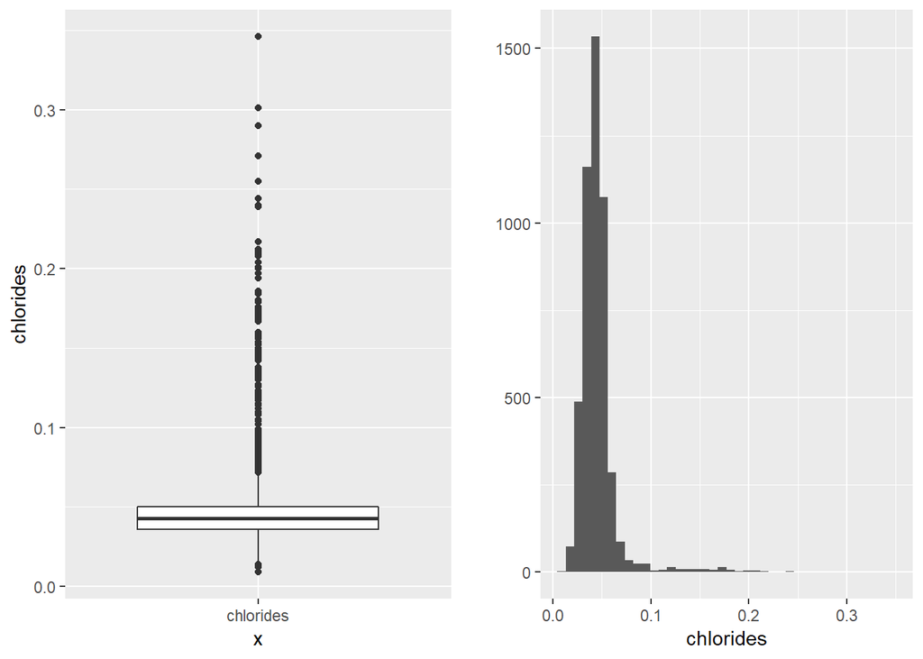

```
##    Min. 1st Qu.  Median    Mean 3rd Qu.    Max.
## 0.00900 0.03600 0.04300 0.04577 0.05000 0.34600
```

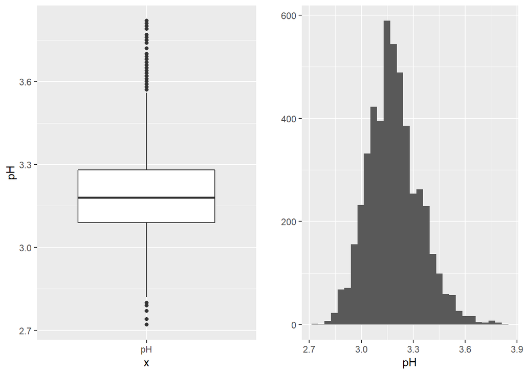

```
##    Min. 1st Qu.  Median    Mean 3rd Qu.    Max.
##   2.720   3.090   3.180   3.188   3.280   3.820
```

> The distribution of pH is almost symmetrical distribution.

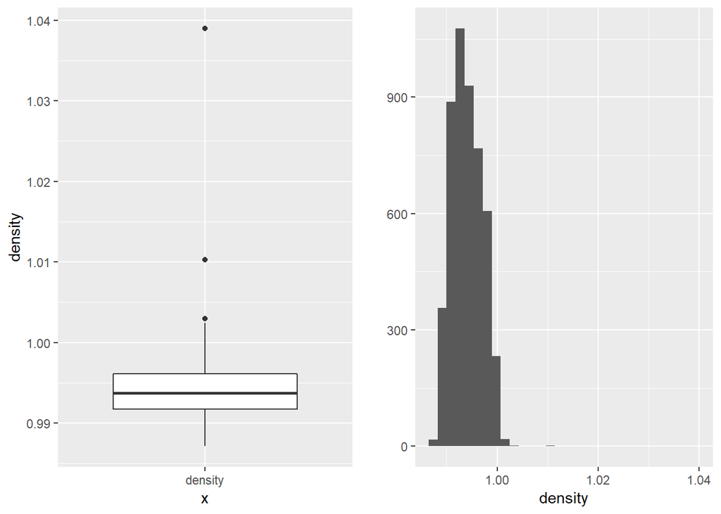

```
##    Min. 1st Qu.  Median    Mean 3rd Qu.    Max.
##  0.9871  0.9917  0.9937  0.9940  0.9961  1.0390
```

> The density distribution is almost symmetrical with some very extreme outliers.

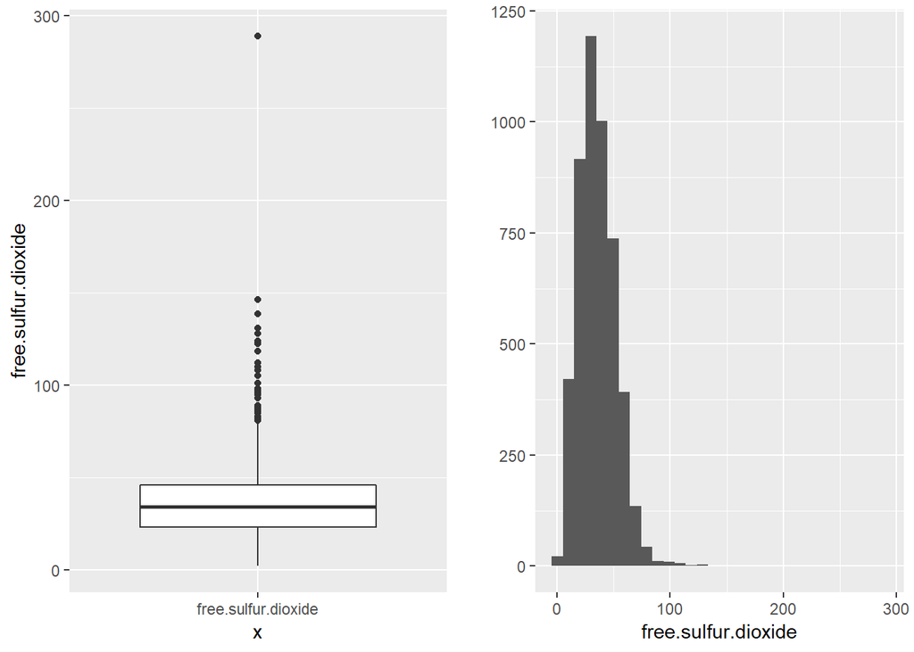

```
##    Min. 1st Qu.  Median    Mean 3rd Qu.    Max.
##    2.00   23.00   34.00   35.31   46.00  289.00
```

> The distribution of the Free Sulfur dioxide is right skewed with a very high outlier at 289.

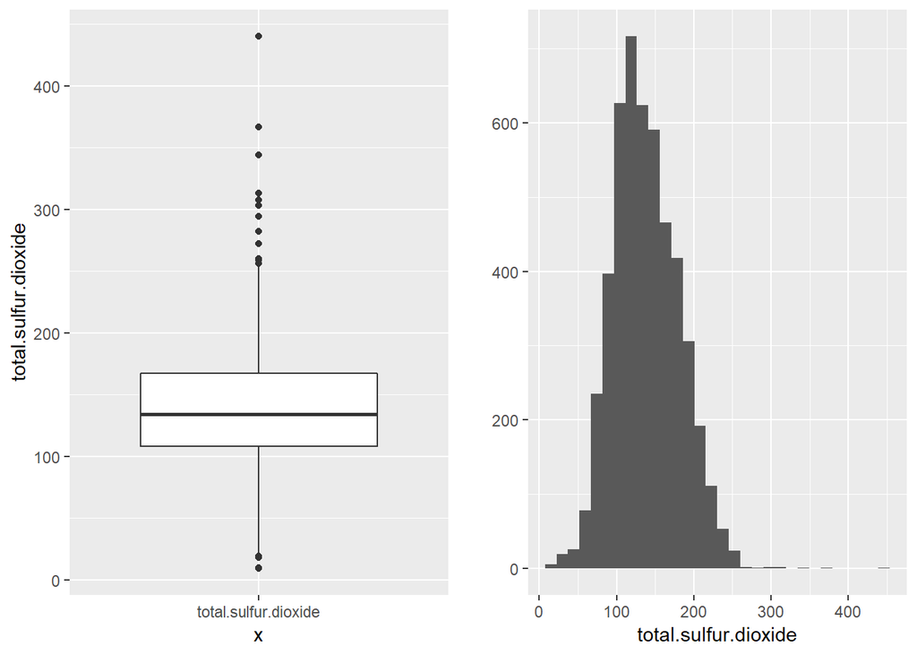

```
##    Min. 1st Qu.  Median    Mean 3rd Qu.    Max.
##     9.0   108.0   134.0   138.4   167.0   440.0
```

> Looking at “total.sulfur.dioxide” boxplot, we can see that the distribution of the Total Sulfur Dioxide is nearly symmetrical with some very high outliers.

# Univariate Analysis

### The dataset’s structure:

The data set original shape was 4898 rows by 12 columns. All variables are numerical except for the only categorical variable **quality** which is the output of the other variables. After that, we added a new categorical variable **quality.buckets**. So, the number of columns changed to 13. After adding the variable, we have noticed that the vast majority of the wines are rated as a good quality.

### The main feature:

The main feature would be the “quality”. So, we will see how other variables affect it.

### Other features that will support the investigation:

I think the “alcohol” and the “residual sugar” will have a positive effect on the quality. Also, “alcohol” will have a negative effect on the density while the “residual sugar” will have a positive effect. I would assume that there will be a negative correlation between the “pH” and the “acidity” because higher “acidity” will mean lower “pH”.

### Added variables:

I have added the **quality.buckets** variable to group the **quality** variable into three main classifications: low, good and high. This will help us to have a better look at relation between the quality and the other attributes, because some qualities have very few number of entries.

### distribution of the data:

While there was some data with normal distributions like “PH”, There were some variables with very huge outliers. Some of the outliers are affected by each other like the outlier in the “density” and the “residual sugar” or the “free sulfur dioxide”" and the “total sulfur dioxide”. Also, the “sulfates” and the “fixed acidity” have right-skewed distribution.

# Bivariate Plots Section

I will start by creating a correlation graph to determine which variables have strong correlation and which don’t. Then I will graph those with strong correlation and calculate their correlation coefficient. Also, in order to get rid of outliers, I have put some limits for some variables.

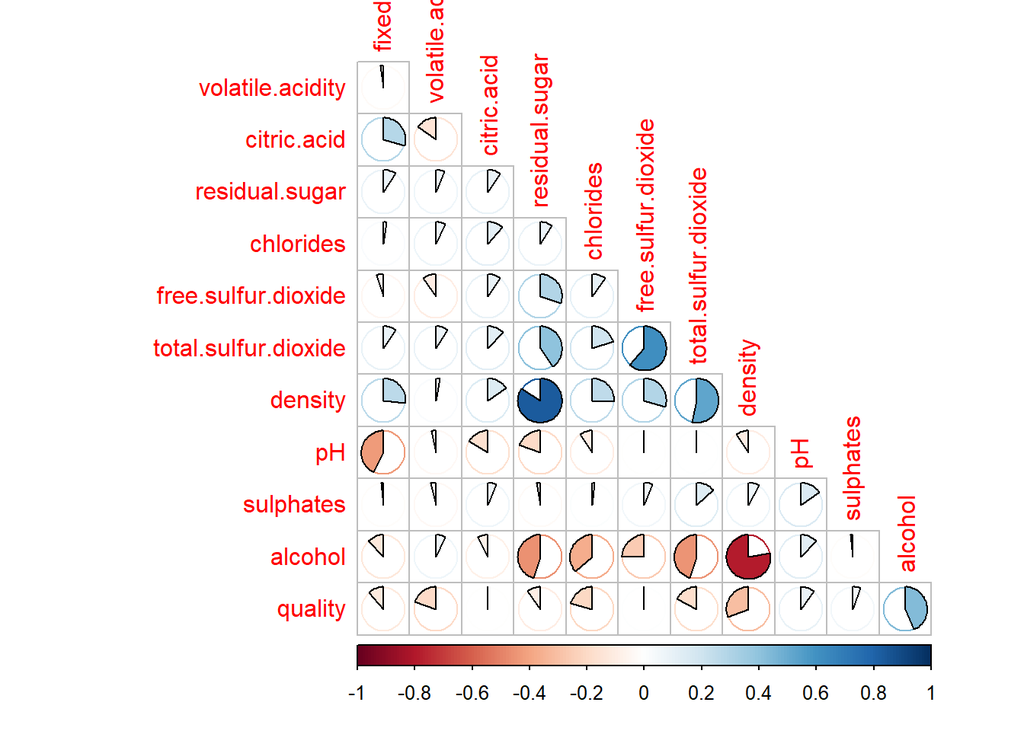

> As we can see, there are some very strong correlations, but the vast majority is very weak correlation.So, we will focus on the strong and moderate correlations.

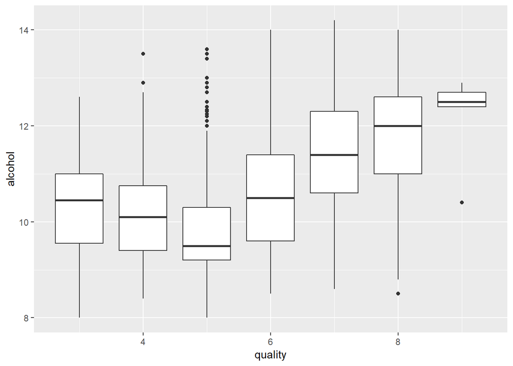

```
## [1] 0.4355747
```

> symmetrical speaking, we can see as the Alcohol percentage increases, we have a higher wine quality.

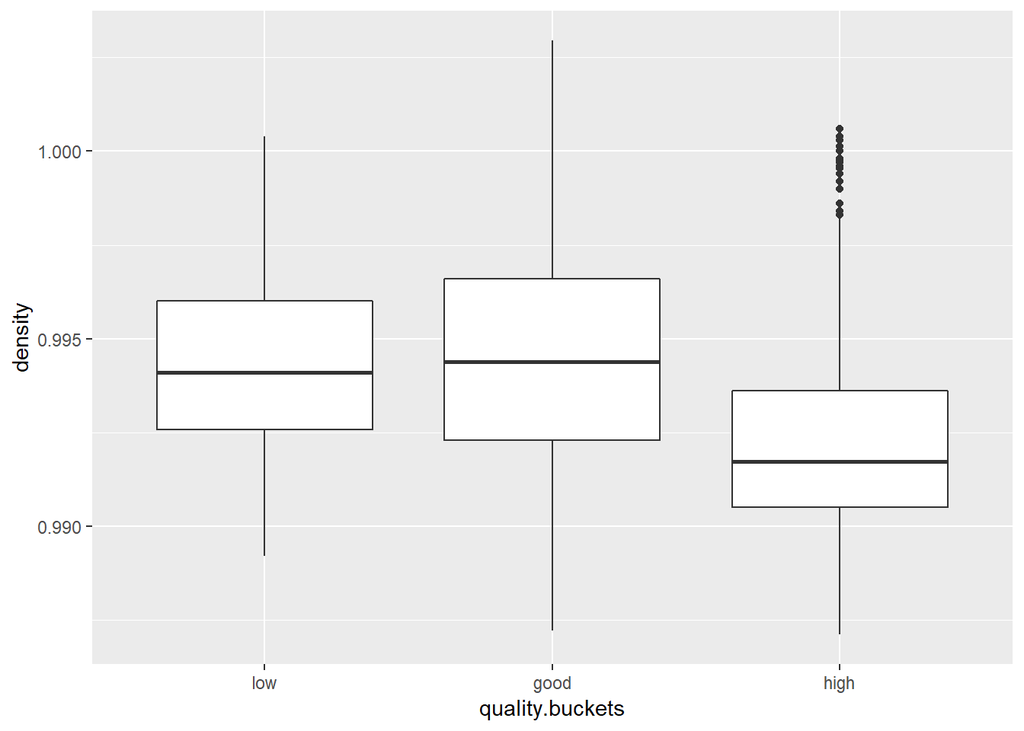

```
## [1] -0.3071233
```

> Wine in the high quality category are less dense than other categories, but that maybe due to high alcohol content in high quality wines, which is causing lower density.

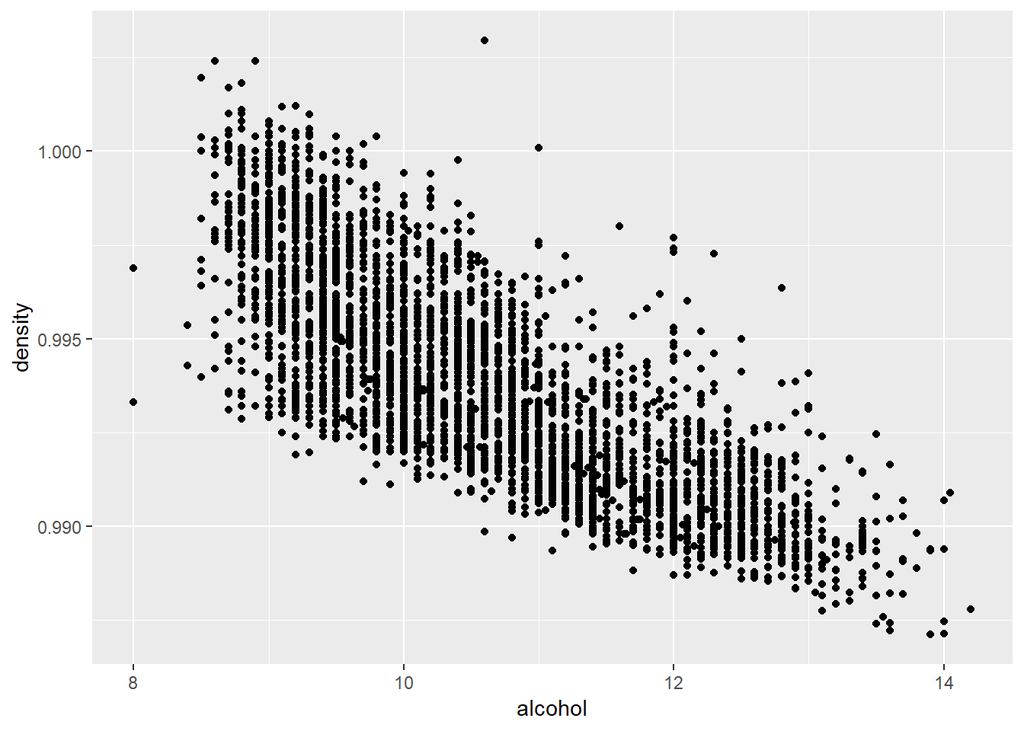

```
## [1] -0.7801376
```

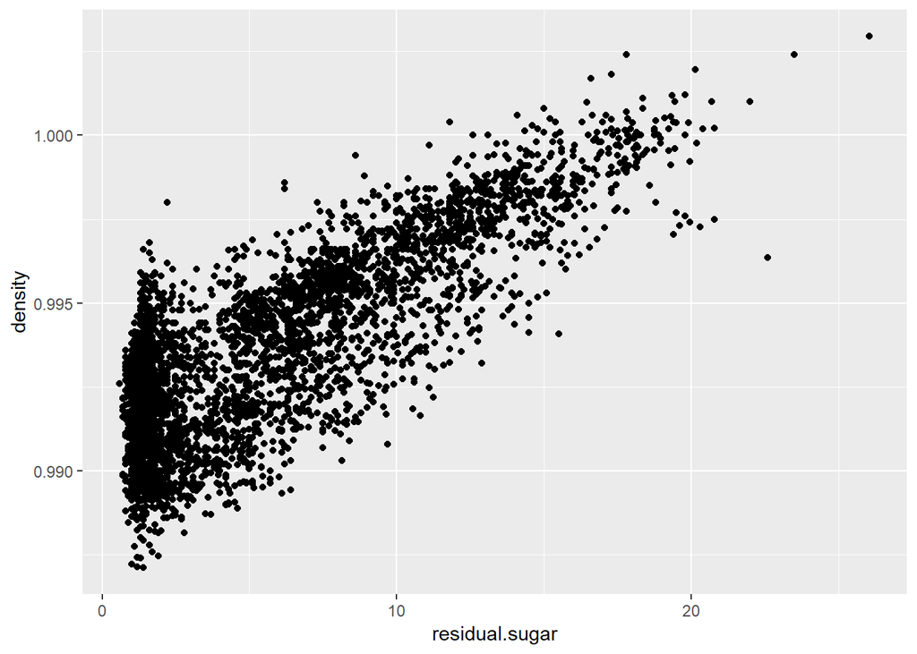

```
## [1] 0.8389665
```

> There is a strong positive correlation between Density and Residual Sugar. Also, we notice that a lot of the points are clustered approximately between 1 and 2, which can be explained by the high peak at the Residual Sugar at the Univariate Plots Section.

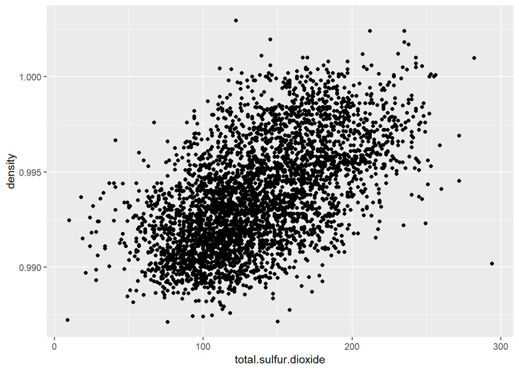

```
## [1] 0.5298813
```

> The Total Sulfur Dioxide and the density have moderate correlation of value (0.53).

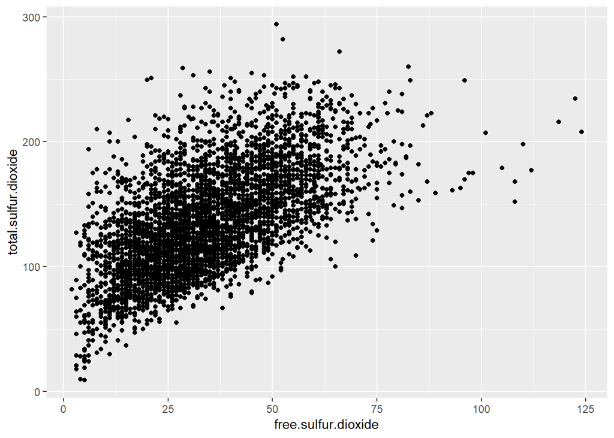

```
## [1] 0.615501
```

> This correlation exists because Total Sulfur Dioxide consist of the Free and bound SO2.

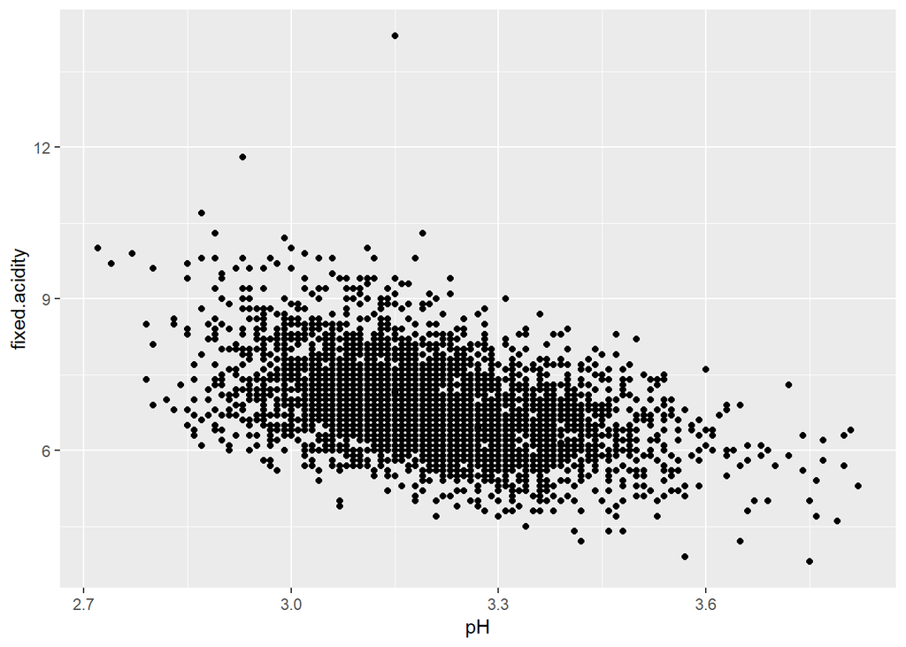

```
## [1] -0.4258583
```

> The correlation between the pH and Fixed Acidity is weak to moderate.

# Bivariate Analysis

looking at the correlation graph, we see that the **alcohol** has the strongest correlation with the **quality** variable, but still with a value of (0.44). The correlation is still considered to be a weak to moderate correlation. Also, the density has a negative weak correlation with value of (-0.31). However, if we look at the **density** vs **residual.sugar** graph, we can see that they have a strong positive correlation equal to (0.84).Also, it has a strong negative correlation of value (-0.78) with **alcohol**. In addition, the **density** have a moderate correlation of value (0.53) with **total sulfur dioxide**. Furthermore, we have a correlation of (-0.43) between **pH** and the **fixed acidity**. These correlations can be explained by looking at the relations between physical and chemical properties.

# Multivariate Plots Section

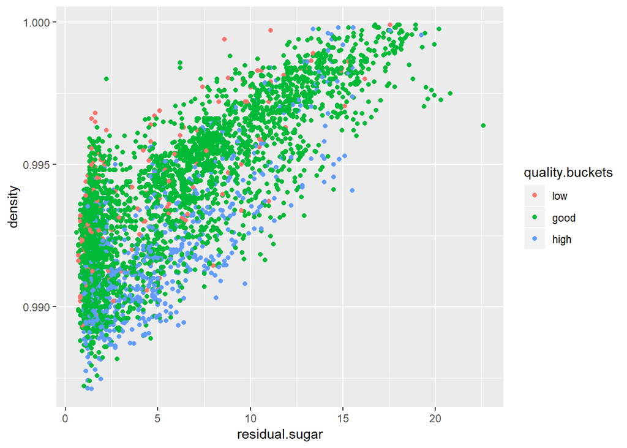

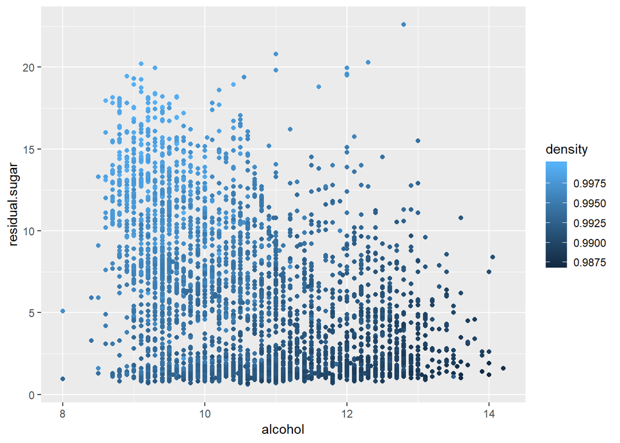

> This is an interesting graph because it illustrates the strong correlation between the density with alcohol and residual sugar.

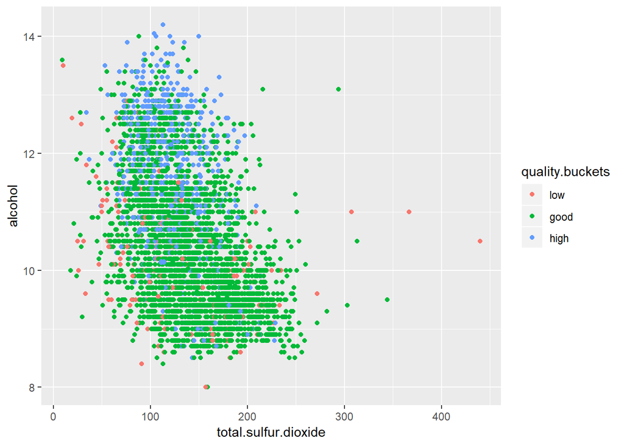

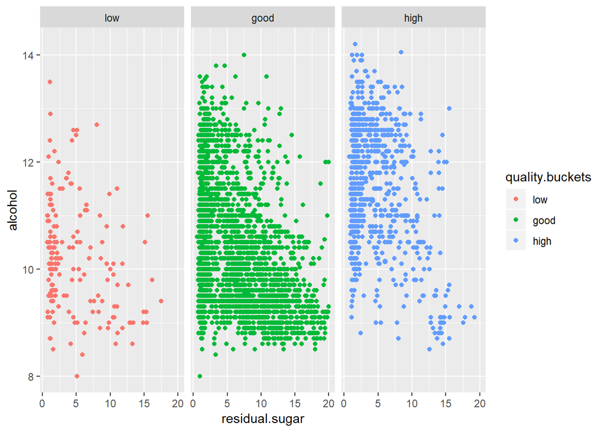

> looking at the graph, we can see that there is a high number of wines that have residual sugar between 1 and 2 despite the quality of the wine. Also, this graph maybe misleading by giving us an impression that the high quality wines are correlated to low residual sugar content if you look at the high quality group without looking at the graph as a whole.

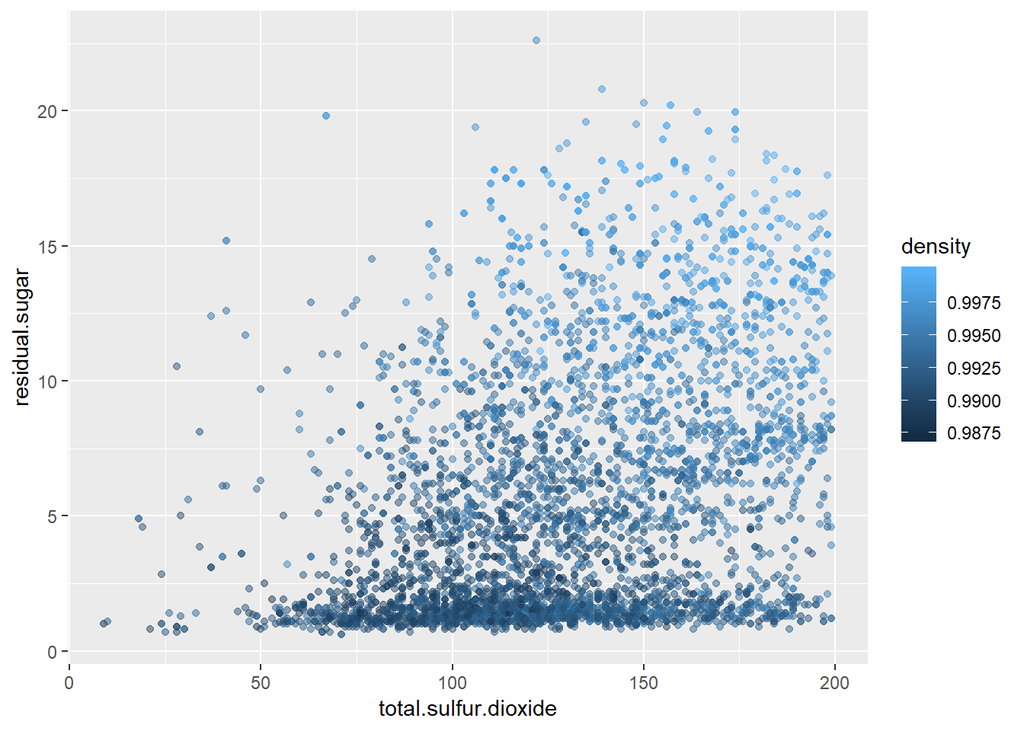

> We can see that as the total sulfur dioxide and residual sugar increase, the density also increases.

# Multivariate Analysis

# Final Plots and Summary

### Plot One

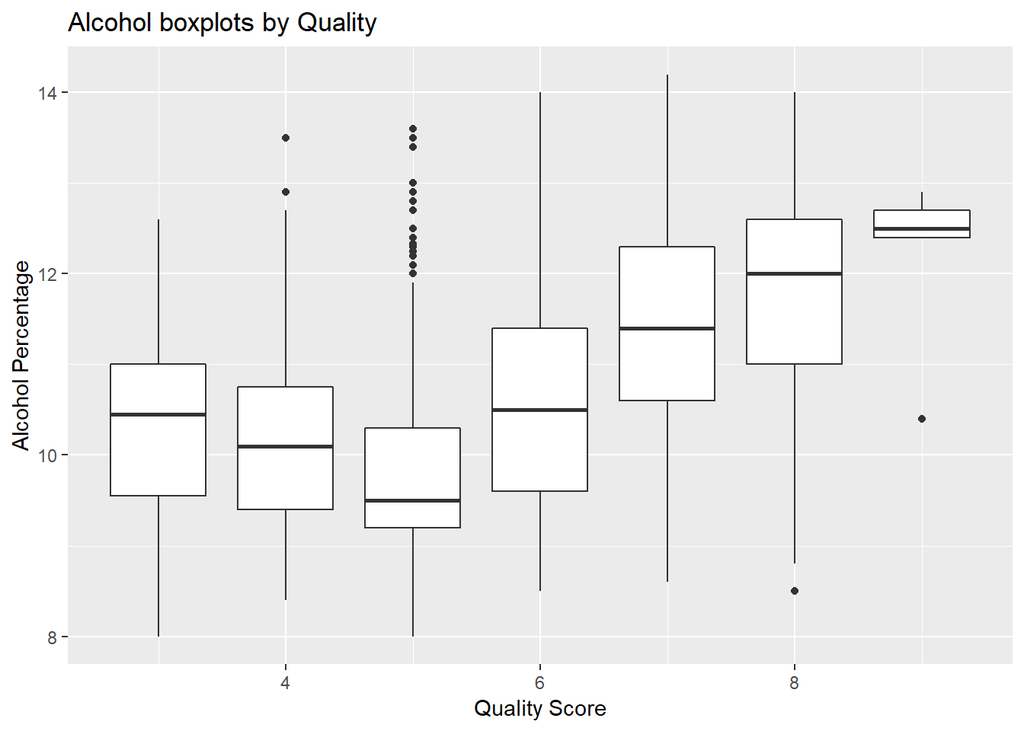

### Description One

Alcohol percentage have the stongest correlation with the quality scores among other variables, and in general we can see that as the alcohol percentage increases, the quality score increases. In this plot, we can see how high quality scores have high alcohol percentage.

### Plot Two

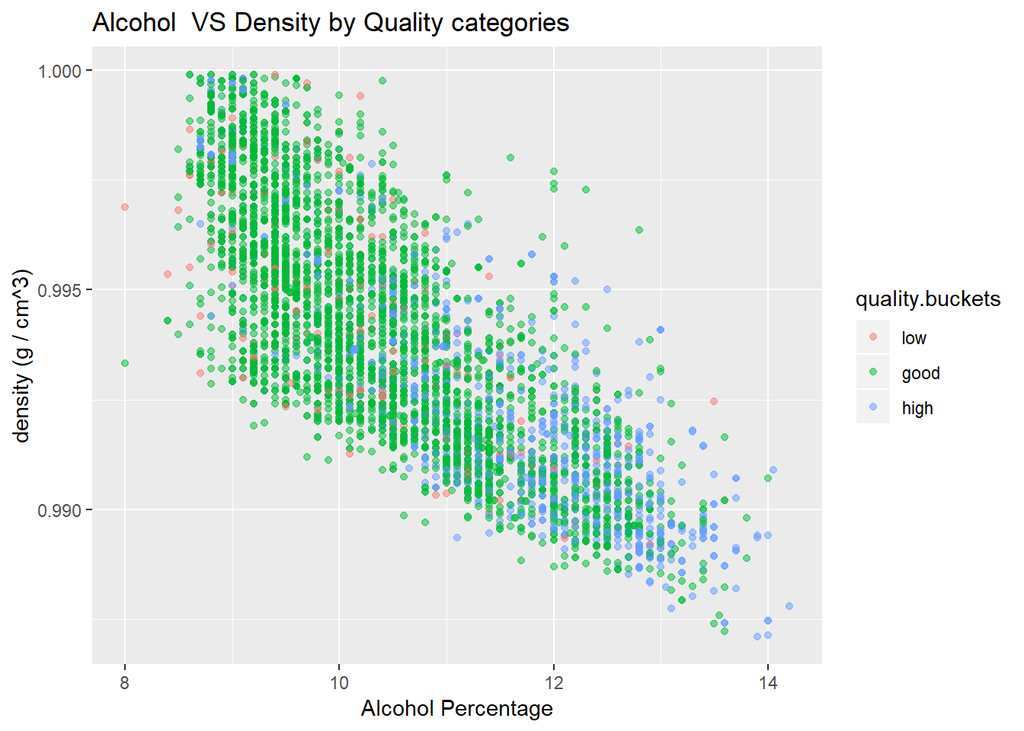

### Description Two

In this plot, we see how the high quality wine are despite with high alcohol percentage, while the good quality wines have less alcohol percentage and higher density. We can also see how strong is the negative correlation between the density and alcohol.

### Plot Three

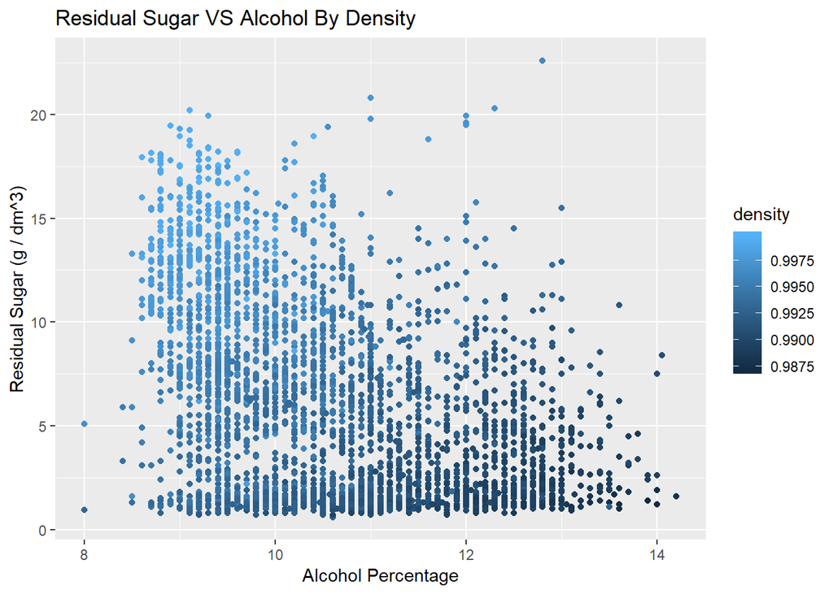

### Description Three

The density has a very strong (the strongest in the dataset) correlation with alcohol and residual sugar. We can see how those strong correlations reflected on the graph and how the density gradually decreases as the alcohol percentage increases, while the residual sugar content decreases.

# Reflection

To sum up, we saw how alcohol is the most related variable to the quality score. Furthermore, how the variables correlate to each other according to their physicochemical properties. There are many factors that are described and could attribute to the quality. It was hard to guess the relationships between these factors and between each factor with the quality. Regarding the quality, there were limited number of some scores, and this can obscure some potential correlations.In the future, it would be helpful to have more variables like the country of origin and the age of the wine to see if ageing the wine will affect the quality. The study was done on one brand only. Comparing the variables among different brands might give more realistic results.